# American Community Survey

### Introduction

The objective of this project was analyzing the data of the 2013 American Community Survey (ACS) to figure out whether an employed PhD makes more money compared to a working bachelor or master degree holder. To do this, I concentrated on B.Sc, MSc, and PhD holders data in ACS.

### Total Number of BSc , MSc, and PhD holders

```r
# Prepare degree codes
degree_codes <- data.frame(SCHL = c(21, 22, 24),
                           Degree = c("Bachelor", "Masters", "Doctorate"))

# Use the pipe operator and chaining
ac_survey_clean <- ac_survey %>%
  tbl_df() %>%
  na.omit() %>%
  filter(SCHL %in% c(21,22,24)) %>%
  inner_join(degree_codes)

# Group by SCHL and count each group
degree_holders <- ac_survey_clean %>%
  group_by(Degree) %>%
  summarize(count = n())

# Print out degree_holders
degree_holders
```

```
## Source: local data frame [3 x 2]
##
##      Degree count
##      <fctr> <int>
## 1  Bachelor 40561
## 2 Doctorate  3000
## 3   Masters 17680
```

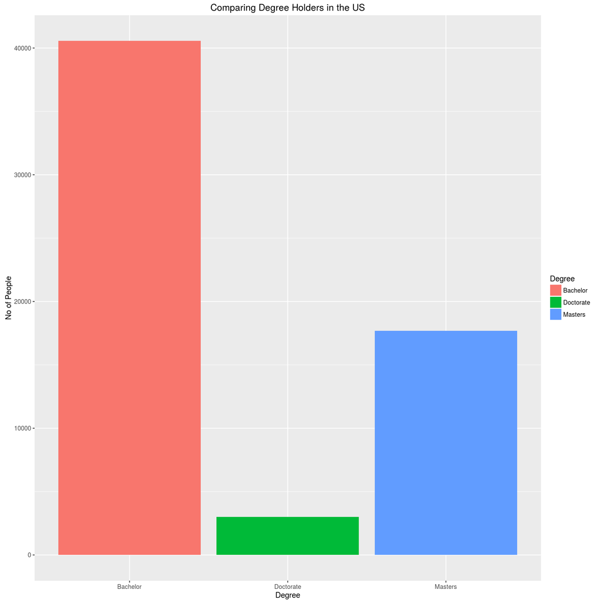

```r
# Visualize the number of Bachelor, Master and PhD holders
ggplot(degree_holders, aes(x = Degree, y = count, fill = Degree)) +
  geom_bar(stat = "identity") +
  xlab("Degree") +
  ylab("No of People") +
  ggtitle("Comparing Degree Holders in the US")
```

The visualization of the data was done using the ggplot2 package.

### Do PhD’s Earn more?

Next, I needed to figure out whether it’s a smart career choice moneywise to pursue a PhD.I created a new data set (named `income`). Income is created by taking 5000 times a random sample of 1000 observations from The American Community Survey. For each sample `min()`, `max()`, `median()`, and `IQR()` is calculated.

```r
# Take 5000 random samples of 1000 observations & calculate median income
over_thousand <- ac_survey_clean %>%
  filter(PINCP > 1000) %>% # exclude obserations with income under 1000
  group_by(Degree)

freq <- 5000 # 5000 samples
income <- NULL
for (i in 1:freq) {
  # Select 1000 observations
  sample <-  sample_n(over_thousand, 1000)

  # Calculate stats by degree
  sample_stats <- summarise(sample,
                            MinIncome = min(PINCP),
                            MaxIncome = max(PINCP),
                            MedianIncome = median(PINCP),
                            IncomeRange = IQR(PINCP))

  income <- rbind(income, sample_stats)
}
```

`income` can now be used to create three boxplots of Median income for each degree level:

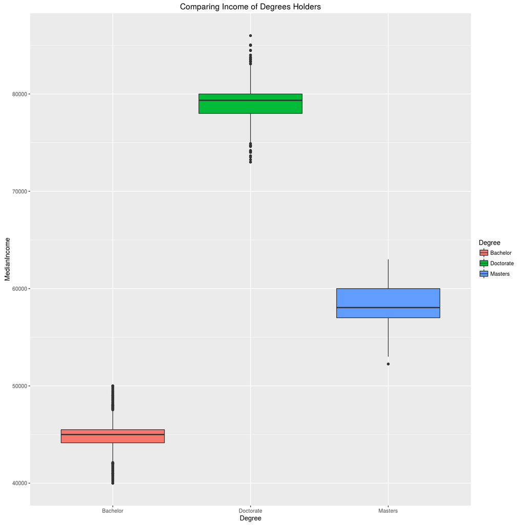

```r
# Create the boxplots
ggplot(income, aes(x = Degree, y = MedianIncome, fill = Degree)) +
  geom_boxplot() +
  ggtitle("Comparing Income of Degrees Holders")
```

The graph clearly shows it is a smart career move to pursue a PhD.